## Introduction

### House prices can often be completely unpredictable and can be quite crazy so we aim to predict house prices using the Boston Housing dataset. The dataset contains information on various factors affecting housing prices in Boston, such as crime rate, number of rooms per dwelling, and property tax rates. By understanding the relationships between these factors we can determine exactly how much effect each one has on house prices so we can have a better understanding of what goes into determining the price of a house. It might even let us get a house that is undervalued by the market.

## What is regression?

### Regression is a statistical technique used to model relationships between a dependent variable and some independent variables. Linear regression assumes a linear relationship between the dependent variable and the independent variables. It applies a line of best fit that tries to predict the data based off of certain weightings

## Data Understanding

### First, we should examine the exact features of the dataset that we are working with. Some of the features we have are CRIM (crime rate per capita), RM (average number of rooms per dwelling), LSTAT (percentage of lower status population), TAX (property tax rate per $10,000), and PTRATIO (pupil teacher ratio by town). We should make a heatmap so we can figure out exactly which features are correlated with each other and use them to draw understandings about house prices.

## Pre-Processing

### We will also have to pre process the data to ensure that it is clean and workable. This will ensure that are datas results are not obscured by random noise or other features in the data that we do not want to. We will replace the missing values with the mean values. We will also drop any duplicates to ensure no duplicates are present. We will also get rid of infinite values and strip the names so that we are not thrown off by anything

```python
import numpy as np
import pandas as pd
import matplotlib.pyplot as plt
import seaborn as sns
from sklearn.model_selection import train_test_split
from sklearn.linear_model import LinearRegression, Ridge
from sklearn.preprocessing import StandardScaler, PolynomialFeatures
from sklearn.metrics import mean_squared_error


data = pd.read_csv(r"C:\Users\adith\Downloads\bostnhouse\HousingData.csv")

print(data.info())
print(data.describe())

data.fillna(data.mean(), inplace=True)
data.drop_duplicates(inplace=True)


data.replace([np.inf, -np.inf], np.nan, inplace=True)


data.columns = data.columns.str.strip().str.lower().str.replace(' ', '_')

print(data.head())
```

```
<class 'pandas.core.frame.DataFrame'>
RangeIndex: 506 entries, 0 to 505
Data columns (total 14 columns):
 #   Column   Non-Null Count  Dtype
---  ------   --------------  -----
 0   CRIM     486 non-null    float64
 1   ZN       486 non-null    float64
 2   INDUS    486 non-null    float64
 3   CHAS     486 non-null    float64
 4   NOX      506 non-null    float64
 5   RM       506 non-null    float64
 6   AGE      486 non-null    float64
 7   DIS      506 non-null    float64
 8   RAD      506 non-null    int64
 9   TAX      506 non-null    int64
 10  PTRATIO  506 non-null    float64
 11  B        506 non-null    float64
 12  LSTAT    486 non-null    float64
 13  MEDV     506 non-null    float64
dtypes: float64(12), int64(2)
memory usage: 55.5 KB
None
             CRIM          ZN       INDUS        CHAS         NOX          RM  \
count  486.000000  486.000000  486.000000  486.000000  506.000000  506.000000
mean     3.611874   11.211934   11.083992    0.069959    0.554695    6.284634
std      8.720192   23.388876    6.835896    0.255340    0.115878    0.702617
min      0.006320    0.000000    0.460000    0.000000    0.385000    3.561000
25%      0.081900    0.000000    5.190000    0.000000    0.449000    5.885500
50%      0.253715    0.000000    9.690000    0.000000    0.538000    6.208500
75%      3.560263   12.500000   18.100000    0.000000    0.624000    6.623500
max     88.976200  100.000000   27.740000    1.000000    0.871000    8.780000

              AGE         DIS         RAD         TAX     PTRATIO           B  \
count  486.000000  506.000000  506.000000  506.000000  506.000000  506.000000
mean    68.518519    3.795043    9.549407  408.237154   18.455534  356.674032
std     27.999513    2.105710    8.707259  168.537116    2.164946   91.294864
min      2.900000    1.129600    1.000000  187.000000   12.600000    0.320000
25%     45.175000    2.100175    4.000000  279.000000   17.400000  375.377500
50%     76.800000    3.207450    5.000000  330.000000   19.050000  391.440000
75%     93.975000    5.188425   24.000000  666.000000   20.200000  396.225000
```

[output cut: 9 more lines]

```
75%     16.955000   25.000000
max     37.970000   50.000000
      crim    zn  indus  chas    nox     rm   age     dis  rad  tax  ptratio  \
0  0.00632  18.0   2.31   0.0  0.538  6.575  65.2  4.0900    1  296     15.3
1  0.02731   0.0   7.07   0.0  0.469  6.421  78.9  4.9671    2  242     17.8
2  0.02729   0.0   7.07   0.0  0.469  7.185  61.1  4.9671    2  242     17.8
3  0.03237   0.0   2.18   0.0  0.458  6.998  45.8  6.0622    3  222     18.7
4  0.06905   0.0   2.18   0.0  0.458  7.147  54.2  6.0622    3  222     18.7

        b      lstat  medv
0  396.90   4.980000  24.0
1  396.90   9.140000  21.6
2  392.83   4.030000  34.7
3  394.63   2.940000  33.4
4  396.90  12.715432  36.2
```

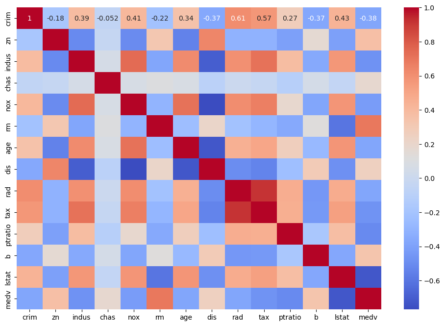

```python
plt.figure(figsize=(12, 8))
sns.heatmap(data.corr(), annot=True, cmap="coolwarm")
plt.show()
```

### The heatmap tell us that the average number of rooms per dwelling have a strong correlation with the value of the home. We can also see that there is a strong inverse relationship between the percentage of low status people and the value of the home

### Experiment 1

### In the first experiment, we use Linear Regression, which is one of the simplest and most commonly used algorithms for regression tasks. Linear Regression tries to find the best fitting linear relationship between the input features and the target variable. The model assumes that the relationship between features and the target is linear. We will use all of the features to predict our home value.

```python
X = data.drop(columns=["medv"])
y = data["medv"]

X_train, X_test, y_train, y_test = train_test_split(X, y, test_size=0.2, random_state=47)

scaler = StandardScaler()
X_train_scaled = scaler.fit_transform(X_train)
X_test_scaled = scaler.transform(X_test)
```

```
Linear Regression RMSE: 4.933914182912892
```

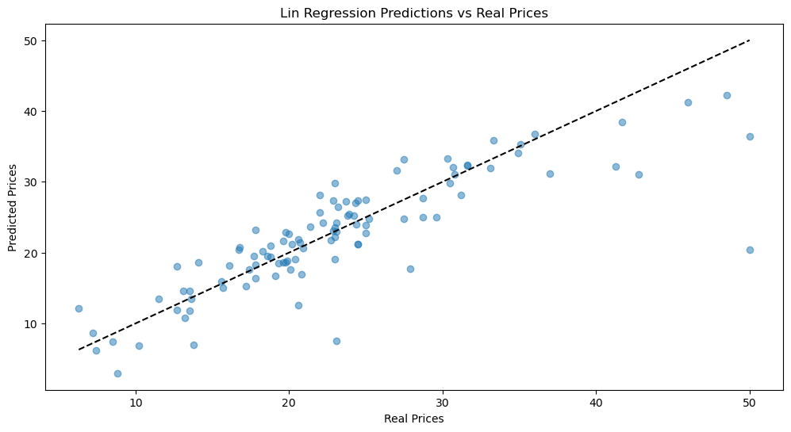

```python
lr = LinearRegression()
lr.fit(X_train_scaled, y_train)
y_pred_lr = lr.predict(X_test_scaled)
rmse_lr = np.sqrt(mean_squared_error(y_test, y_pred_lr))
print(f"Linear Regression RMSE: {rmse_lr}")

plt.figure(figsize=(12, 6))
plt.scatter(y_test, y_pred_lr, alpha=0.5)
plt.plot([min(y_test), max(y_test)], [min(y_test), max(y_test)], '--k')
plt.xlabel("Real Prices")
plt.ylabel("Predicted Prices")
plt.title("Lin Regression Predictions vs Real Prices")
plt.show()
```

### We have got a RMSE of 4.93 which means on average we are 4.93 off of the actual value with our prediction so in the context of house prices it is not a bad amount to be off by

## Experiment 2

```
Polynomial Regression (degree=2) RMSE: 4.232418911497604
```

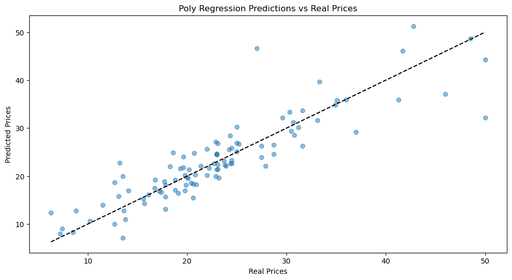

```python
poly = PolynomialFeatures(degree=2, include_bias=False)
X_train_poly = poly.fit_transform(X_train_scaled)
X_test_poly = poly.transform(X_test_scaled)

lr_poly = LinearRegression()
lr_poly.fit(X_train_poly, y_train)
y_pred_poly = lr_poly.predict(X_test_poly)
rmse_poly = np.sqrt(mean_squared_error(y_test, y_pred_poly))
print(f"Polynomial Regression (degree=2) RMSE: {rmse_poly}")

plt.figure(figsize=(12, 6))
plt.scatter(y_test, y_pred_poly, alpha=0.5)
plt.plot([min(y_test), max(y_test)], [min(y_test), max(y_test)], '--k')
plt.xlabel("Real Prices")
plt.ylabel("Predicted Prices")
plt.title("Poly Regression Predictions vs Real Prices")
plt.show()
```

### As we can see the RSME has improved so we know that it is a better estimate now as it is off less on average.

### Experiment 3

### In this experiment, we use Ridge Regression, which is similar to Linear Regression but includes regularization. Regularization prevents the model from relying too much on certain features by keeping the coefficients smaller which ends ups reducing the risk of overfitting.

```
Ridge Regression RMSE: 4.934604931419477
```

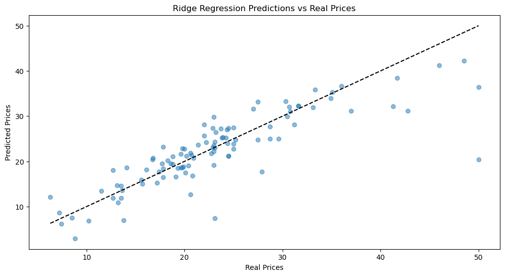

```python
ridge = Ridge(alpha=1.0)
ridge.fit(X_train_scaled, y_train)
y_pred_ridge = ridge.predict(X_test_scaled)
rmse_ridge = np.sqrt(mean_squared_error(y_test, y_pred_ridge))
print(f"Ridge Regression RMSE: {rmse_ridge}")

plt.figure(figsize=(12, 6))
plt.scatter(y_test, y_pred_ridge, alpha=0.5)
plt.plot([min(y_test), max(y_test)], [min(y_test), max(y_test)], '--k')
plt.xlabel("Real Prices")
plt.ylabel("Predicted Prices")
plt.title("Ridge Regression Predictions vs Real Prices")
plt.show()
```

### References

```python
https://www.youtube.com/watch?v=GMF4Td7KtB0

https://www.youtube.com/watch?v=nqNdBlA-j4w
```

[output not shown]